# Regression analysis: more theory and extensions

# What is linearity?

```r
knitr::include_graphics("ioc-8-linearity.pdf")
```

[figure not shown]

# OLS

```r
knitr::include_graphics("ioc-8-ols.pdf")
```

[figure not shown]

# Categorical predictors

```r
knitr::include_graphics("ioc-8-categorical.pdf")
```

[figure not shown]

# Interactions

```r
knitr::include_graphics("ioc-8-interaction.pdf")
```

[figure not shown]

# Lab materials

The purpose of the lab work is to demonstrate a full data analysis from scratch using regressions.

From the larger pool of data sets within the , the 2015 face-to-face post-election study is made available for you as csv or Rdata. This script loads directly the Rdata version via `load()`.

You’ll find the showcards as well to help you locate the variables but beware you’ll need to look through your variable names (`names()`) because the showcard names don’t always correspond exactly to the data set variable names. Don’t worry you can still figure it out if I could as well…

Whenever exploring variables, check measurement level. Most of the stuff is here is labeled factor (read categorical) variables, including ordinal variables on 10-point scales that many of you will want to treat as continuous variables, be sure to assign numerical values to these.

This set of exercises will explore variables and test hypotheses related to the following research question primarily: Are older and more educated people more politically interested?

**(H1) Growing older increases political interest.**

**(H2) Having a university degree increases political interest.**

Given the nature of this assignment, we will extend these models to demonstrate (a) model fit comparison, (b) interaction effects, (c) quadratic terms. An additional variable introduced will be frequency of watching political news on television.

## Descriptives.

Code below loads the data and prints the number of observations as well as the number of variables.

```r
load(file="bes2015.Rdata")
c(obs=nrow(bes2015),vars=ncol(bes2015))
```

```
##  obs vars
## 2987  476
```

Locate appropriate variables in data set. There is a 4-category political interest variable, a03; as well as a 10-category variable measuring how much attention respondent pays to politics in general, k01. I’m more comfortable using latter as a continuous dependent variable.

*FAQ: For the purposes of the assignment, it’s OK to use 4 or 5-category dependent variables. You’ll run model diagnostics and see for yourself how much they violate assumptions. Likewise, I’m not saying that a 10 category variable is always superior.*

```r
summary(bes2015$k01)
```

```
##                       Not stated                       Don't know
##                                0                               10
##               0 Pay no attention                                1
##                              257                              128
##                                2                                3
##                              206                              308
##                                4                                5
##                              234                              444
##                                6                                7
##                              355                              433
##                                8                                9
##                              323                              128
## 10 Pay a great deal of attention
##                              161
```

To which end I’ll need to swap the strings to actual numerical values, my solution was:

```r
bes2015$polatt <- NA
bes2015$polatt[bes2015$k01=="0 Pay no attention"] <- 0
bes2015$polatt[bes2015$k01=="1"] <- 1
bes2015$polatt[bes2015$k01=="2"] <- 2
bes2015$polatt[bes2015$k01=="3"] <- 3
bes2015$polatt[bes2015$k01=="4"] <- 4
bes2015$polatt[bes2015$k01=="5"] <- 5
bes2015$polatt[bes2015$k01=="6"] <- 6
bes2015$polatt[bes2015$k01=="7"] <- 7
bes2015$polatt[bes2015$k01=="8"] <- 8
bes2015$polatt[bes2015$k01=="9"] <- 9
bes2015$polatt[bes2015$k01=="10 Pay a great deal of attention"] <- 10
```

Yes you can use `ifelse()`.

Age is measured appropriately but it has funky range:

```r
summary(bes2015$Age)
```

```
##    Min. 1st Qu.  Median    Mean 3rd Qu.    Max.
##   -1.00   37.00   51.00   51.26   66.00   97.00
```

```r
length(bes2015$Age[bes2015$Age==-1]) # gets the number of observations coded -1
```

```
## [1] 32
```

Just swapping those 32 `-1` values with NAs whatever they stood for originally. FAQ: Make sure NA is not a string, “NA” but a logical constant without quotation marks, NA.

```r
bes2015$age <- bes2015$Age
bes2015$age[bes2015$age==-1] <- NA
```

Education is a 20 category variable, use `summary()` to explore. This would be very tricky to use as is. Questions arise if you really want a prediction at each of these 20 levels, if treated as nominal measure. If treated as continuous variable, you’d need to make a case of hierarchy between these levels, and at some points I am really unsure of those hierarchies (e.g. Nursing qualification, Teaching qualification). If you know what you’re doing, you can recode so that it’s a proper ordinal variable. I will just get out the 3 categories that imply higher education, and create a university education dummy variable:

```r
bes2015$uni <- 0 # making 0 default so that I don't have to code 16 non-uni categories 0s
bes2015$uni[bes2015$education=="Not stated"] <- NA
bes2015$uni[bes2015$education=="Postgraduate degree"] <- 1
bes2015$uni[bes2015$education=="First degree"] <- 1
bes2015$uni[bes2015$education=="Univ/poly diploma"] <- 1
```

Finally, to use later in the extended models, using frequency of watching news on television, an ordinal variable, as continuous predictor. Code below swaps default string labels to numerical values.

```r
bes2015$tv <- NA # NA is default now, will hand-recode the actual values 1--5 &
                 # this way missing data is already coded appropriately
bes2015$tv[bes2015$k04=="None, No time at all"] <- 1
bes2015$tv[bes2015$k04=="Less than 1/2 hour"] <- 2
bes2015$tv[bes2015$k04=="1/2 hour to 1 hour"] <- 3
bes2015$tv[bes2015$k04=="1 to 2 hours"] <- 4
bes2015$tv[bes2015$k04=="More than 2 hours"] <- 5
```

## Exporatory plots.

Note these may be checking assumptions already such as the distribution of X (read: *is there* a distribution of X, **not** about normality) or just exploring good candidates for outliers.

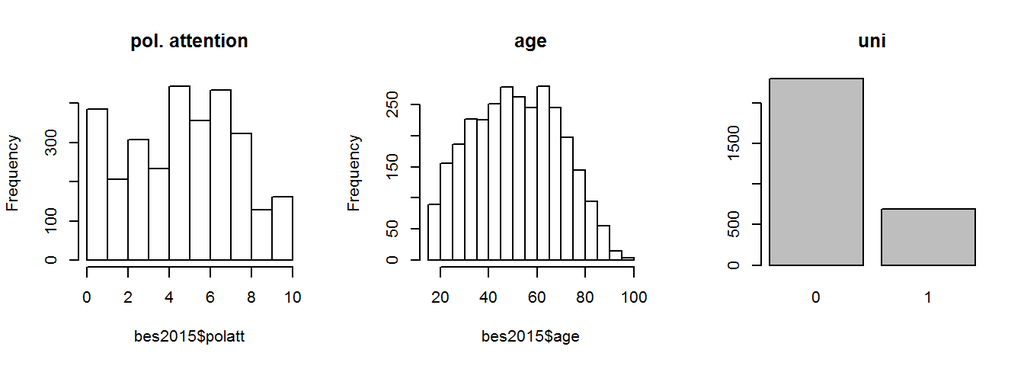

```r
par(mfrow=c(1,3))
hist(bes2015$polatt,main="pol. attention")
hist(bes2015$age,main="age")
plot(x=factor(bes2015$uni),main="uni")
```

## Bivariate plots.

Good first step to look for linear relationships, the examples below seem to be confirmatory. Note I’m using boxplots because scatterplots are not terribly informative with ordinal variables (check it). Up to you how to visualise a bivariate relationship. If proper continuous variables both, scatterplot may be the way go to.

*FAQ: at this stage of exploration, just by looking at the raw data, you may rule out linearity and opt for some solution of curvilinearity. See this explaining what you’re supposed to see in the first place. I also noted in class that you may want to avoid overfitting, which is when the pattern looks somewhat like a curve, but one line explains most of it just fine, in which case I would opt for that simpler linear solution.*

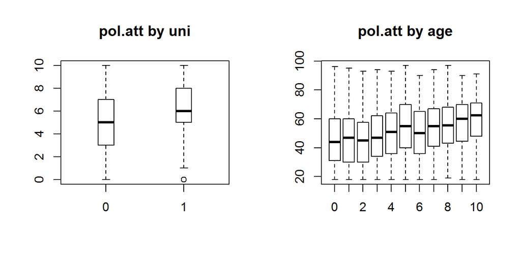

```r
par(mfrow=c(1,2))
boxplot(bes2015$polatt ~ bes2015$uni, boxwex=.2, main="pol.att by uni")
# swapped y and x for better readability below, otherwise
# would get a box at each year of age
boxplot(bes2015$age ~ bes2015$polatt,main="pol.att by age")
```

The meaning of the outlier point in university education-by-political attention: *technically*, observation is drawn out because it lies outside of 1.5 x of pol. attention’s full distribution in given category, an arbitrary measure that you can tweak yourself `?boxplot()`. More *substantively*, those 0’s on political attention are `unexpected’ under university education, given the rest of the values.

# Models

Fitting in response to the following instructions:

**m1** `regress age and university education on political attention, store it in m1’

```r
m1 <- lm(polatt ~ age + factor(uni), data=bes2015)
```

**m2** `regress age, university education, and frequency of following pol news on tv on political attention’

```r
m2 <- lm(polatt ~ age + factor(uni) + tv, data=bes2015)
```

**m3** `regress age, and an interaction effect between university education and tv on political attention’

```r
m3 <- lm(polatt ~ age + factor(uni) * tv, data=bes2015)
```

**m4** `regress age squared, university education, and frequency of following pol news on tv on political attention’

```r
bes2015$age.s <- bes2015$age^2
m4 <- lm(polatt ~ age + age.s + factor(uni) + tv, data=bes2015)
```

*FAQ: It does not matter if you include the single (additive) terms on top of the interaction term (ie* `+ tv + factor(uni)`*), it will be treated as the same thing. You get those terms in the output anyway, see next section.*

## Interpretation of model summary.

Regression summary output roughly around three sections of interest: (1) info on residuals, (2) info on parameter* estimates & hypothesis test around each, (3) info on model fit inc. $R^2$ and the $F$ statistic.

**read: anything unknown. You know the raw X and Y’s, you don’t know the intercept and the slope(s).*

```r
summary(m1)
```

```
##
## Call:
## lm(formula = polatt ~ age + factor(uni), data = bes2015)
##
## Residuals:
##     Min      1Q  Median      3Q     Max
## -7.4931 -1.8004  0.1464  1.9279  6.5302
##
## Coefficients:
##              Estimate Std. Error t value Pr(>|t|)
## (Intercept)  2.814303   0.155999   18.04   <2e-16 ***
## age          0.036415   0.002722   13.38   <2e-16 ***
## factor(uni)1 1.619863   0.116489   13.91   <2e-16 ***
## ---
## Signif. codes:  0 '***' 0.001 '**' 0.01 '*' 0.05 '.' 0.1 ' ' 1
##
## Residual standard error: 2.63 on 2944 degrees of freedom
##   (40 observations deleted due to missingness)
## Multiple R-squared:  0.09703,    Adjusted R-squared:  0.09641
## F-statistic: 158.2 on 2 and 2944 DF,  p-value: < 2.2e-16
```

By now we are familiar with each of these. Residuals summary shows the range of u’s with a median close to 0, which we will investigate thoroughly in the Assumptions section.

### Effect sizes, p values, confidence intervals.

The point estimate of the intercept is 2.81 which is the value of the DV if age is set to 0 (there are no 0 aged persons in our data set though thus substantively meaningless) and if we are in the reference category of the uni variable, namely ‘no university education’. Age point estimate informs us that a unit change in it (ie year of age) increases predictions about political attention with 0.03, seems rather small on a 10 point scale but multiply it by 18 and add it to the intercept to get an 18 year old, non-university educated person’s political attention: `18 * 0.03 + 2.81 = 3.35`. Compare with a prediction of a 30 year old, non-university educated person: `30 * 0.03 + 2.81 = 3.71`. The university estimate tells us that, no matter where we are on the age scale, our predictions will be constantly higher by 1.61 thus an 18 year old’s political attention is predicted at `3.35 + 1.61 = 4.96` or a 30 year old’s political attention is predicted at `3.71 + 1.61 = 5.32`.

As the terms I used above imply, point estimates are our best guess as to where the estimates ‘really’ are but those subject to error. We hand-calculated errors of estimates previously, now we can just trust R with those numbers. We conducted t-tests to check if our estimates are likely to be 0, and translated our t-statistics into p values, again all that stuff given here in the output. $p$ values confirm that each of these three point estimates fit within 99% **confidence intervals** or even stricter. In other words, within 99% confidence intervals, you can rule out that either of those estimates are 0. You can (and should for this assignment…) get and report the specific numerical values at any confidence interval via

```r
confint(m1,level=0.90) # for 90 per cent confidence intervals
```

```
##                    5 %       95 %
## (Intercept)  2.5576262 3.07097923
## age          0.0319375 0.04089341
## factor(uni)1 1.4281957 1.81152949
```

which shows neatly how the point estimates in the model summary for each of these three are right in the middle of these values. Note that they are all above 0. An insignificant value would sit within CIs including 0.

*FAQ1: Stating the p value or the level of the confidence interval is two sides of the same coin. Thus* > 99% CI *is p* < .01. > 95% CI *is p <* 0.05. *But these are both about probabilities, whereas confint() translates these probabilities into actual values of the estimate such as ‘what values are still likely beyond the mean given 95% CI’*

*FAQ2: Not very nice to write that p =* 0. *There is always a probability of the null hypothesis, whatever small. Just write p* < 0.001.

*FAQ3: The stars in the output are only intelligible with the guide under the table, giving away what they mean. Don’t use them in a sentence.*

*FAQ4: Stuff like* 2e-8 *is scientific notation for* $2*10^{-8}$ *, an efficient way to write* 0.00000002. *If in doubt use* `format(2e-8,scientific=FALSE)`.

*FAQ5: A small point estimate such as* 0.001 *can be statistically significant, just means that your model found enough evidence behind an otherwise very small effect.*

### Model fit.

Finally, **$R^2$** is a measure of explained variance over total variance thus you can take it as a percentage. There is a lot of details written up in the previous handout about this inc. hand calculation. Luckily, R puts this in the model summary so there’s no need to calculate it: it’s approx. 10 per cent. Take this as 10 per cent of all variation across people (making up the voting age population of the UK excluding Northern Ireland), in terms of how much attention they pay to politics, is explained by university education and age. Heuristically, some interpret this as, given 100 people and all you know about them is their age and whether they went to university, you’ll be able to guess the political attention score of 10 people, but your guess of the remaining 90 is still a shot in the darkness. Whether that performance is satisfactory, that’s up to your judgment. I’d treat this as a fair chunk variation explained, given how random people are especially when it comes to answering political surveys.

The difference between adjusted and multiple $R^2$ is that former takes into account the number of predictors and should yield a more conservative estimate. Sometimes the differences are negligible, but whenever available, do go for the conservative estimate.

**F-statistic** and its p-value: in this case it’s *not* used for model comparison (that’s section below), but take it as an alternative to $R^2$ showing if the independent variables explain Y any better than an uninformative model that has no IVs but only an intercept. A significant F-test then means that our model does bring in new information with age and education. A non-significant F test would mean that there is nothing gained with this particular combination of IVs (it *may* be because of multicollinearity, but I would check for that separately to make sure, see under Assumptions. Otherwise this may just be because of inclusion of irrelevant IVs).

### Further models, interactions, quadratic term.

Next, so that I don’t flood the handout with +3 model outputs, here is some highlights of the extended models:

Following news on TV has a positive and significant effect on political attention, namely:

```r
coef(m2)[4]
```

```
##       tv
## 1.190481
```

```r
confint(m2)[4,]
```

```
##    2.5 %   97.5 %
## 1.110671 1.270291
```

We were worried that this variable measures the same thing (or too close anyway) as the DV, political interest. Is watching news on TV is just a different way to measure political interest? This is not a methodological problem, more like substantive: why would you regress the same variable on itself? If that’s the case, I would expect the $R^2$ to go very very high.

It turned out to be still far from 100%, but it’s much higher than the previous model’s:

```r
summary(m2)$r.squared
```

```
## [1] 0.301289
```

in fact the subsequent models don’t really surpass this result by changing functional form. Does this mean we found a very good predictor (the more you flip through news the more attention you will pay generally, as a consequence), or does this mean we just found one way people can pay attention to politics, in which case the relationship is not causal. These are the kinds of questions you take up in a research paper, but for the assignment, you may discard.

**Interaction effect** significant in model 3:

```r
coef(m3)[3:5]
```

```
##    factor(uni)1              tv factor(uni)1:tv
##       2.0988403       1.2431396      -0.2634328
```

```r
confint(m3)[3:5,]
```

```
##                      2.5 %     97.5 %
## factor(uni)1     1.5797587  2.6179220
## tv               1.1546820  1.3315972
## factor(uni)1:tv -0.4551523 -0.0717134
```

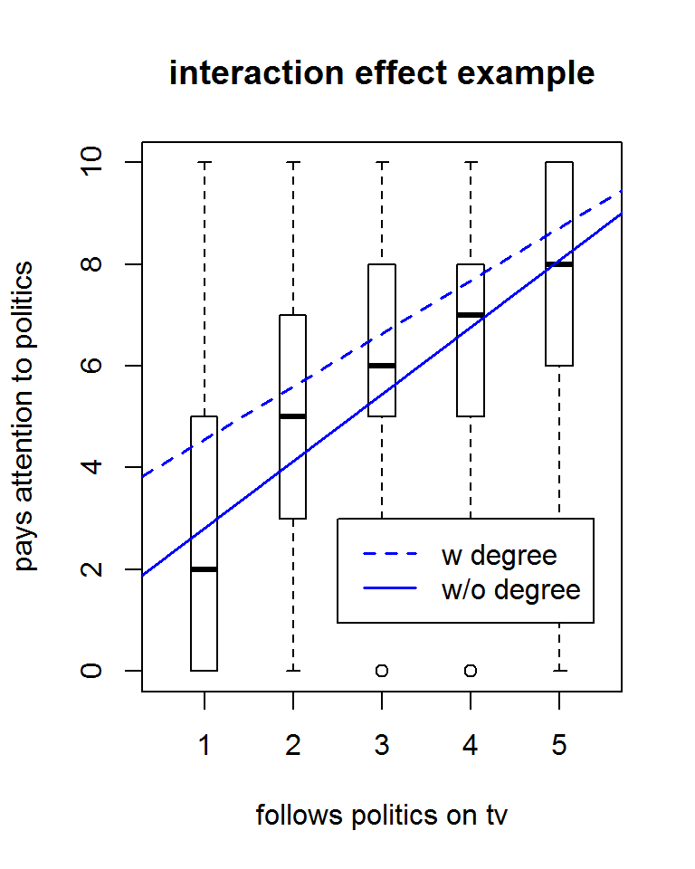

```r
boxplot(bes2015$polatt ~ bes2015$tv,
        xlab="follows politics on tv",
        ylab="pays attention to politics",
        main="interaction effect example",boxwex=.3)
abline(lm(polatt~tv,data=bes2015[bes2015$uni==0,,]),col="blue",lwd=1.5)
abline(lm(polatt~tv,data=bes2015[bes2015$uni==1,,]),col="blue",lwd=1.5,lty=2)
legend(2.5,3,legend=c("w degree","w/o degree"),
             lty=2:1, bg = "white", pt.cex = .6, lwd=1.5, col="blue")
```

**Quadratic term** included in model 4 is significant. For a thorough explanation see link in FAQ under bivariate plots. This basically confirms that though unit change in age increases attention to politics (coefficient comparable to previous ones) the rate of increase slows down kind of pointing downwards. If the quadratic term was positive, you’ assume the rate of increase is faster so that it would point upwards.

## Comparing model fit.

Though you can do some eye balling on the $R^2$ measures, it’s not normally recommended to compare models alone. Get a better sense of differences between models via the F test which is roughly comparing sets of model fit statistics, adjusted for degrees of freedom and number number of new regressors, and *tests the null hypothesis that the difference between the two model fit statistics are 0*. If you reject your null hypothesis, you can normally conclude that the model with a larger $R^2$ really improved on model fit and thus explains more variation in your DV.

```r
# F = ((r2_new-r2_old)/number of new regressors) / ((1-r2_new)/df)
# where df is the degrees of freedom

# then use pf to locate the F value on the probability distribution
# pf(F,1*,df,lower.tail=F)
# *1 is the between groups degrees of freedom n-1 (there are two models, so it's 1),
# df is the degrees of freedom in your model

r2_old <- summary(m1)$r.squared
r2_new <- summary(m2)$r.squared

# F is
((r2_new-r2_old)/3)/((1-r2_new)/m2$df.residual)
```

```
## [1] 285.9118
```

```r
# the probability of the null hypothesis, that differences = 0 is
pf(285.91, 1, m2$df.residual, lower.tail = F)
```

```
## [1] 2.816436e-61
```

The extremely low p-value suggests that we can reject the null hypothesis that m2 and m1 explain the same portion of variation in political attention, and we can conclude that the one with frequency of following politics on tv explains more.

It’s a good idea to carry out this test or an which is something I recommended to some of you before we discussed the F-test. To make this work, make sure observations are the same across your models!

# Regression assumptions

Will discuss broken down by steps, but I will refer to the following diagnostic plots:

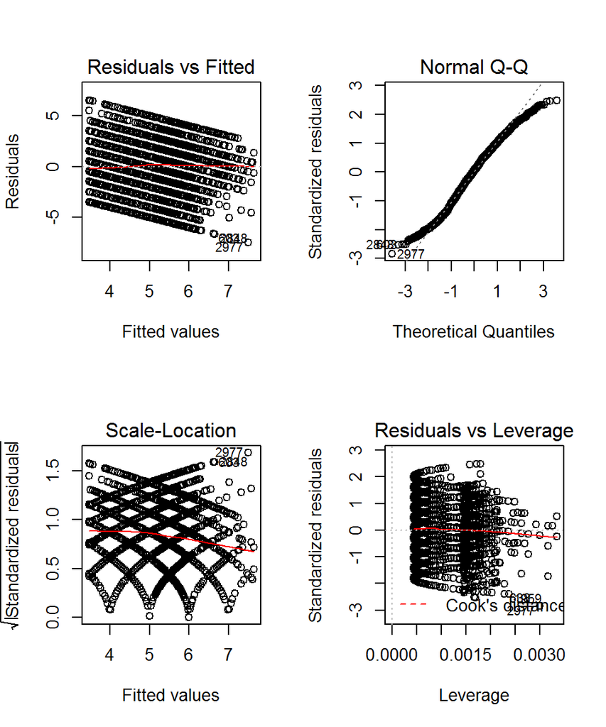

```r
par(mfrow=c(2,2))
plot(m1)
```

If I had to give an overview, I’d say: my residuals are normally distributed (QQ-plot) with a mean of zero (red lines in the rest of them, I don’t mind the slight deviation at the end)…

The fourth plot informs me that I shouldn’t be worried about outliers, I don’t see anything outside ‘Cook’s distance’, those would be separated by red dashed lines, as some measure of how much leverage those outliers have on my predictions. But do note that there is no assumption on outliers.

Step-by-step,

*The mean error around model predictions is 0.* Easiest via diagnostic plots, also you get a median residual in the model summary, or you can just confirm by

```r
# E(u) = 0
mean(m1$residuals)
```

```
## [1] 3.590582e-17
```

and get additional certainty if you can’t decide if it’s ‘zero enough’, that you *can’t* rule out that 0 within 95% confidence intervals (that’s a good thing now):

```r
t.test(m1$residuals)
```

```
##
##  One Sample t-test
##
## data:  m1$residuals
## t = 7.4138e-16, df = 2946, p-value = 1
## alternative hypothesis: true mean is not equal to 0
## 95 percent confidence interval:
##  -0.09496156  0.09496156
## sample estimates:
##    mean of x
## 3.590582e-17
```

Normal distributions are best explored via QQ plots () which is given in the diagnostic plots, but you may get a rough idea via a histogram as well (scenarios: forgot the `qqnorm()` command, your audience has no clue what a QQ plot means, tricky exam question etc.), where the vertical bars should vaguely draw out a bell curve:

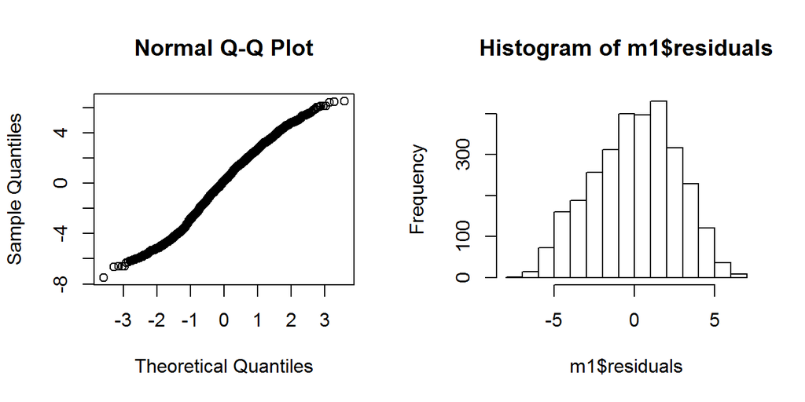

```r
# u ~ N(0, sigma^2)
par(mfrow=c(1,2))
qqnorm(m1$residuals)
hist(m1$residuals)
```

```r
# and the Q-Q plot
```

close enough.

*Is there autocorrelation? Does error increase at certain levels of predictions?* The first test demonstrates that residuals and fitted values do not co-vary,

```r
# cov(X, u) = 0
cov(m1$residuals,m1$fitted.values)
```

```
## [1] -4.442425e-15
```

```r
cor.test(m1$residuals,m1$fitted.values)
```

```
##
##  Pearson's product-moment correlation
##
## data:  m1$residuals and m1$fitted.values
## t = -1.064e-13, df = 2945, p-value = 1
## alternative hypothesis: true correlation is not equal to 0
## 95 percent confidence interval:
##  -0.03610691  0.03610691
## sample estimates:
##           cor
## -1.960614e-15
```

and an additional check on that 0, given two continuous variables, is given via a correlation test, where not being able to rule out the correlation coefficient of 0 is again a good thing.

```r
# car::ncvTest(m1)
# lmtest::bptest(m1)
```

*Do I have enough observations for 3 parameters?* Yes.

```r
# b >> n
nrow(bes2015) # number of observations
```

```
## [1] 2987
```

```r
length(m1$coefficients) # number of parameters.
```

```
## [1] 3
```

*Is there multicollinearity?* If your X’s are super highly correlated, your model may not be able to decide where to attribute effect sizes. That’s only really a problem if you fail to detect significant effects, but testable easily via

```r
# the two continuous predictors in m2. Do not worry about this with dummy variables
cor.test(bes2015$age,bes2015$tv)
```

```
##
##  Pearson's product-moment correlation
##
## data:  bes2015$age and bes2015$tv
## t = 15.415, df = 2942, p-value < 2.2e-16
## alternative hypothesis: true correlation is not equal to 0
## 95 percent confidence interval:
##  0.2396176 0.3064751
## sample estimates:
##       cor
## 0.2733765
```

Conclusion: though there is some moderate correlation between these two Xs, (a) since I have no problems detecting effects, and (b) it’s not really that high, e.g. above .7, I can just say I did not violate any assumptions on this.

*Is there specification bias?* Tricky. Model spec is (1) up to theory, that will tell you what to include, and (2) as such it’s a process, there may be no definite answers available. *BUT* your diagnostic plots may show problems that could potentially be due to specification problems: if your error increases at certain predictions, you may have failed to include an important covariate! Try adding something and see if it fixes the problem with the errors.

*Distribution of Xs* just means that, for instance, if age can range between 0-100, I don’t have all my observations stuck at 18, meaning there is no variation on age. Likewise, if 100% of my sample is university educated, I can’t add uni as IV. You see that stuff at the beginning at descriptives. **Do not** check for normality on X.